# FA511 - Standardkurver (Eksempel Ibuprofen)

Author

JK

# 1. Load Tidyverse-pakke

**Click here for code**

```r
library("tidyverse")
library(here)
```

# 2. Datatabel

Hvis datasæt er lille, er det nemmest at indtaste værdier. Det er altid en god idé at skrive kommentarer i koden, fx koncentrationsenheder, navnet af API, brugte forkortelser osv. (µg/ml, ibuprofen, DS = dilution series).

**Click here for code**

```r
ibuprofen <- data.frame(
  concentration = c(4,8,12,16,20),
  DS1 = c(0.191, 0.367, 0.559, 0.741, 0.930),
  DS2 = c(0.183, 0.383, 0.593, 0.776, 0.931),
  DS3 = c(0.182, 0.384, 0.591, 0.750, 0.935)
)
```

I den næste trin skal der beregnes middelværdi og standardafvigelsen. Der er forskellige muligheder her, og koden her given opfølgende kommandoer (“pipe” angivet med “%<%”).

Obs: Der kunne gives nyt navn; men da der kun tilføjes MW og SD kan der også overskrives den gamle tabel.

**Click here for code**

```r
ibuprofen <- ibuprofen %>%
  rowwise (concentration) %>%
  mutate(mean(c_across(DS1:DS3))) %>%
  mutate(sd(c_across(DS1:DS3)))
```

De nye kolonner med MV og SD bliver automatisk navngivet. Så det er en god idé at give kortere navne. Obs: Igen, vi overskriver den gamle tabel.

**Click here for code**

```r
ibuprofen <- rename(
  ibuprofen,
  y="mean(c_across(DS1:DS3))",
  se="sd(c_across(DS1:DS3))")
```

# 3. Lineær regression

Den næste trin er at lave lineær regression af datapunkter.

**Click here for code**

```r
LR_av <-
  lm(y~concentration,
     subset(ibuprofen)
  )
```

## 4. Graf af standardkurven

Den er en ret kompleks stykke kode… Det er hovedsageligt formatering. Jeg har skrevet nogle kommentarer ind i koden (hvor der skal tilpasses koden, hvis man bruger et andet stof).

**Click here for code**

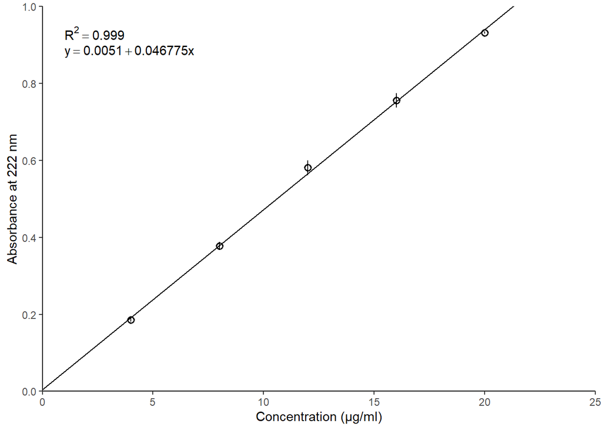

```r
graph <- ggplot(
  ibuprofen,
  aes(x=concentration, y, ymin=y-se, ymax=y+se)
)+
  geom_pointrange(shape=1
  )+
  geom_abline(
    aes(
      intercept=LR_av$coefficients[1],
      slope=LR_av$coefficients[2])
  )+
  # OBS: Her skal der tilpasses akseindstillinger (både x og Y)
  scale_x_continuous(
    limits = c(0,25),
    breaks = c(0,5,10,15,20,25),
    expand = expansion(0)
  )+
  scale_y_continuous(
    limits = c(0,1.0),
    breaks = c(0,0.2,0.4,0.6,0.8,1.0),
    expand = expansion(0)
  )+
  # OBS: Her skal der indsættes korrekt bølgelængde
  labs(
    x="Concentration (µg/ml)",
    y="Absorbance at 222 nm"
  )

# Adding some formatting, OBS: Placering af annotationen skal måske tilpasses
graph + annotate(
  "text",
  y = seq(0.9, 0.95, length=2),
  x=1,
  label=list(
    paste("y ==", LR_av$coefficients[1], " + ", LR_av$coefficients[2], "*x"),
    paste("R^2 ==", signif(summary(LR_av)$r.squared, 4))
  ),
  parse=TRUE,
  hjust=0,
  vjust=1,
)+
  theme_classic()
```

Hvis man ønsker kan man bruge eksport funktionen (panel til højre i bunden hvor grafen er vist) for at få en image-fil (fx jpeg).

Hvis man er færdig med koden og har eksporteret grafen, kan man gemme skriptet (fx FA511_Iburpofen) og tilpasse kode til det næste stof (Sulfadiazin og Paracetamol), som gemmes separat under egen filnavn.